# 雇员流失分析报告

杜耀宗

2019/5/22

#### 摘要

本项目数据来源于优蓝招聘APP，使用Rmarkdown 制作。

```
1.使用探索性数据分析和统计方法分析雇员数据。
2.建立了logistic回归模型和时间序列预测模型。
3.针对雇员高流动性特征，对症下药给出结论建议。
```

### 一、项目基础

本项目旨在分析雇员流失的影响因素，因此从背景、问题、数据等维度全面进行数据分析。

#### 1.1 背景概况

互联网招聘与传统业务招聘共同构成了板块的主体业务。

```
随着互联网招聘板块业务的发展，覆盖到招聘行业的方方面面。在与B端企业的合作过程中，通过优蓝招聘APP入职的雇员，在一段时间间内显示出异常波动，明显的体现是“流失率”过高，为了优化APP用户体验和提高和B端客户合作粘度，协助业务部门产品优化和业务拓展，特展开了针对性的综合分析。
```

#### 1.2 问题提出

1.雇员流失的相关特征？

2.雇员流失的相关因素？

3.雇员流失的模型预测？

#### 1.3 理解数据

本次综合性数据分析由三部分构成。

```
包括主数据、辅助数据和深度访谈构成，旨在从数据层面、问题层面和建议层面全面的分析“雇员流失”的数据的画像、数据特征、因素分析等方面。据来自于优蓝招聘APP后台数据库导出，为合作方雇员数据，约为1.8万条，其中数据包括离职人员数据和在职人员数据，需要进一步区分分析.数据涵盖雇员ID、年龄、学历、性别、时间等信息。时间跨度为2018年11月-2019年4月，为期6个月.
```

### 二、数据清洗

数据清洗从数据的读取、缺失值处理、重复值处理、函数变量分组以及时间一致化等方面进行，对原始数据清理，方便数据可视化绘图以及统计分析、建立预测模型。

#### 2.1数据读取

原始数据读取，发现数据长度为18081，8个变量,包含ID、性别、年龄、学历、籍贯、状态（在职、离职）、入职时间和离职时间。

#### 2.2 缺失值处理

数据集存在NA值5437条，是在职员工数时间缺失，显示为在职状态，无离职时间。因此在计算工龄的时间将剥离此部分。

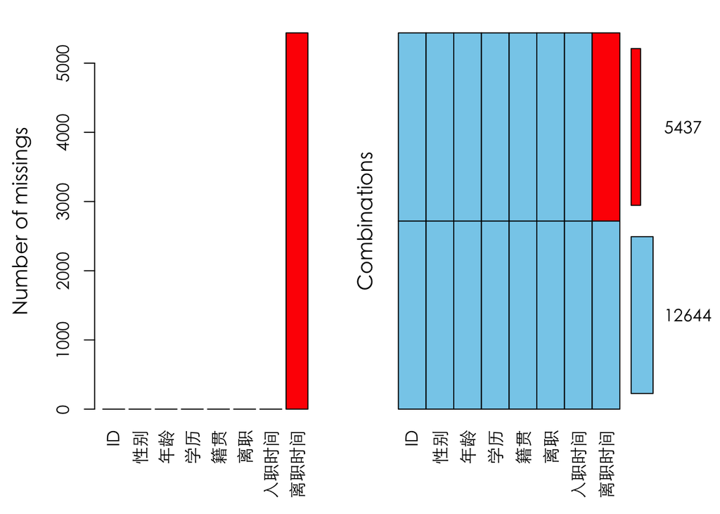

#### 2.3 重复值清理

清理重复值数据1条

#### 2.4 变量的分组

对变量中的籍贯和年龄分组，方便会后续分析。

| ID | 性别 | 年龄 | 学历 | 籍贯 | 离职 | 入职时间 | 离职时间 | 籍贯分组 | 年龄分组 |
| --- | --- | --- | --- | --- | --- | --- | --- | --- | --- |
| 4237 | 男 | 31 | 初中 | 河南省 | 是 | 2018-11-02 | 2018-11-02 | 河南省 | 大于30岁 |

#### 2.5 时间一致性

统一时间格式，方面后续数据处理

| ID | 性别 | 年龄 | 学历 | 籍贯 | 离职 | 入职时间 | 离职时间 | 籍贯分组 | 年龄分组 |
| --- | --- | --- | --- | --- | --- | --- | --- | --- | --- |
| 4237 | 男 | 31 | 初中 | 河南省 | 是 | 2018-11-02 | 2018-11-02 | 河南省 | 大于30岁 |

#### 2.6 时间差计算

工作年龄计，排除未离职雇员数据，计算已经离职雇员数据。

| ID | 性别 | 年龄 | 学历 | 籍贯 | 离职 | 入职时间 | 离职时间 | 籍贯分组 | 年龄分组 | 工龄 |
| --- | --- | --- | --- | --- | --- | --- | --- | --- | --- | --- |
| 4237 | 男 | 31 | 初中 | 河南省 | 是 | 2018-11-02 | 2018-11-02 | 河南省 | 大于30岁 | 0 |

### 三、探索性分析

探索性数据分析，主要展示雇员画像以及分析影响流失的主要因素以及因素之间的相互关系，分析流失率。经过分析，我们发现雇员画像以男性为主，年龄较低，学历水平偏低，来自河南、四川和甘肃来源的雇员最多，超过一半。

#### 3.1 雇员数据画像

雇员的画像包括性别、学历、地区、年龄、工龄、离职率等方面，旨在描绘雇员的基本特征。

##### 3.1.1 男性雇员为主

经过数据统计发现，雇员画像中男性占比77.36%，女性占比22.64%，男性为雇员画像的主要人群。

| 性别 | 频率 | 比例 |
| --- | --- | --- |
| 男 | 13986 | 77.36 % |
| 女 | 4094 | 22.64 % |

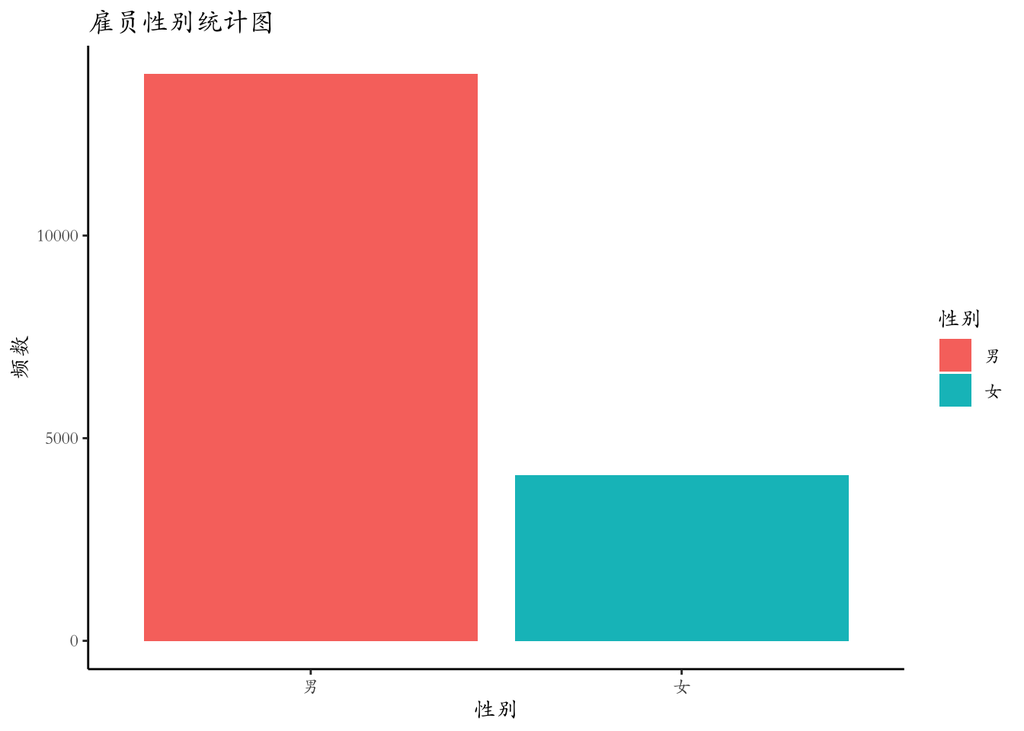

##### 3.1.2 学历水平偏低

| 学历 | 频率 | 比例 |
| --- | --- | --- |
| 初中 | 8531 | 47.18 % |
| 中专 | 5444 | 30.11 % |
| 高中 | 2557 | 14.14 % |
| 大专 | 1548 | 8.56 % |

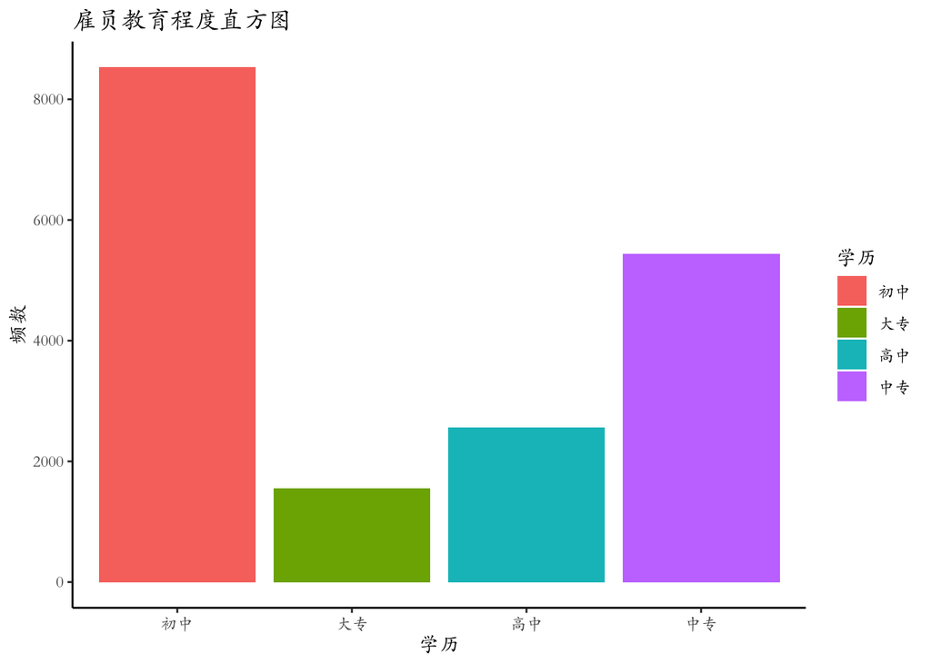

##### 3.1.3 豫川来源近半

| 地区 | 频数 | 比例 |
| --- | --- | --- |
| 河南省 | 6124 | 33.87 % |
| 四川省 | 2162 | 11.96 % |
| 甘肃省 | 1669 | 9.23 % |
| 江苏省 | 1163 | 6.43 % |
| 山西省 | 1025 | 5.67 % |
| 陕西省 | 932 | 5.15 % |
| 安徽省 | 850 | 4.7 % |
| 山东省 | 707 | 3.91 % |
| 云南省 | 568 | 3.14 % |
| 贵州省 | 465 | 2.57 % |

##### 3.1.4 年轻雇员群体

通过分组，将年龄段分成三个层次，如下图。从流失的雇员年龄段来看，20岁以下的员工占比37.38%,20-30岁雇员占比51.86%，30岁以上的占比10.76%，可见雇员整体上非常年轻。

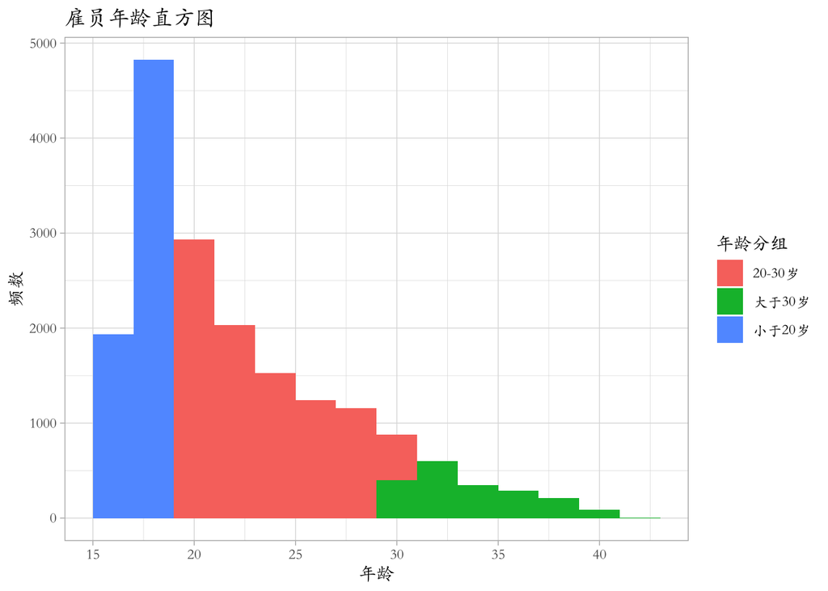

#### 3.2 雇员流失特征

变量相关分析主要围绕雇员流失的工作年龄展开，探索主要的流失因素。

##### 3.2.1 近七成的流失率

从雇员离职率上看，数据显示雇员的离职率达到了69.93%，意味着近7成的流失率。

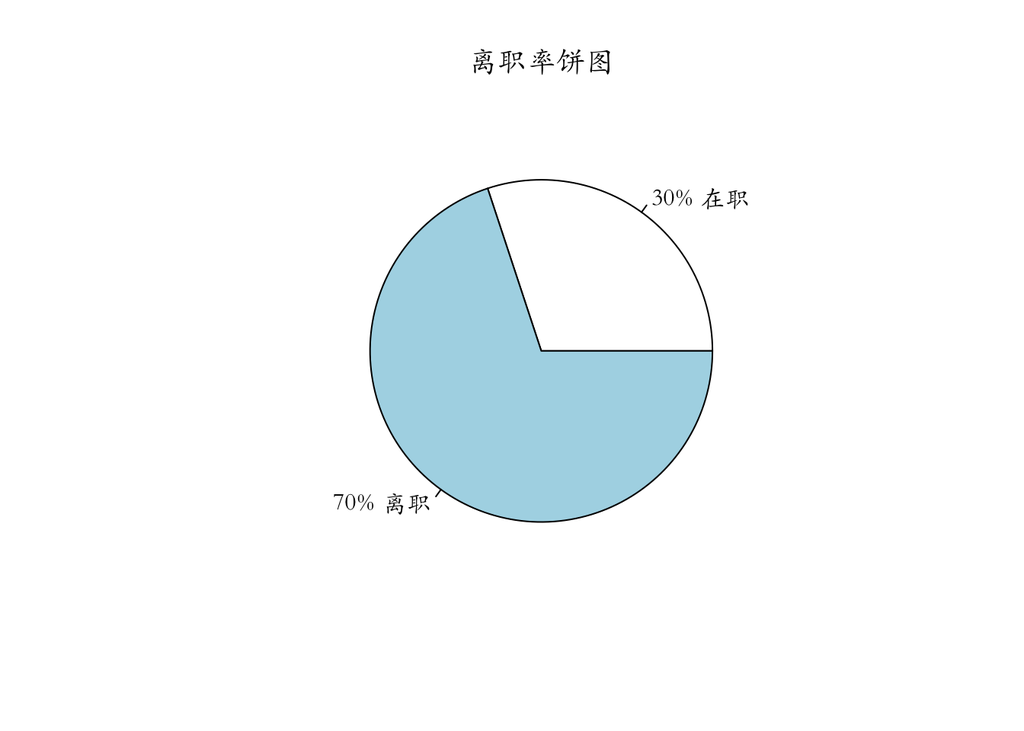

##### 3.2.2 双峰值流失状态

在数据清理的环节中，我们将年龄、籍贯进行了分组，方便在绘图和计算中用到。根据密度图显示，存在两个峰值期，即7天左右和50天左右，是离职的高峰期，密度值非常高。此后，密度图日趋平稳，流失率下降。

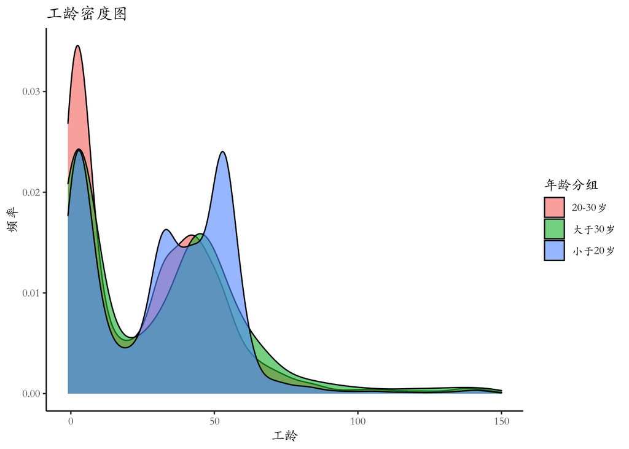

在箱线图中,女性的中位数普遍高于男性，整体上具有较高的稳定性。

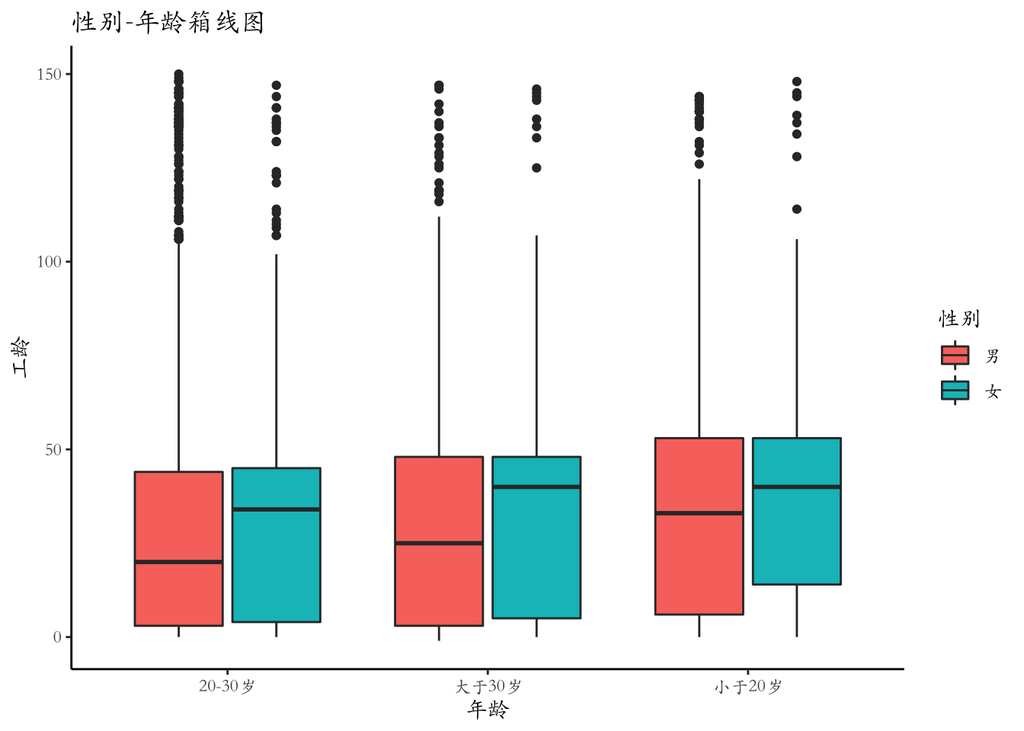

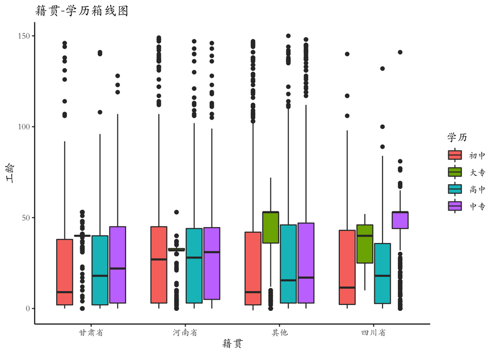

##### 3.2.3 雇员稳定性分析

```
##    Min. 1st Qu.  Median    Mean 3rd Qu.    Max.
##    0.00    4.00   32.00   29.32   47.00  150.00
```

| ID | 性别 | 年龄 | 学历 | 籍贯分组 | 年龄分组 | 工龄 | 工龄分组 |
| --- | --- | --- | --- | --- | --- | --- | --- |
| 4237 | 男 | 31 | 初中 | 河南省 | 大于30岁 | 0 | 1周 |

从年龄和工龄的密度图来看，一周就流失的雇员年龄分布更均衡，可能是受整体环境、管理、制度等原因的影响，与自身的预期相差过大，进而离职，25%的4天就离开了，75%的人工作了47天。而工作了2-8周的人也就是两个月，对工作开始适应，但种种原因导致离开，与一周离开的人的原因截然不同，更多的是接受了环境和与前期，但管理的不善促使了他们用脚投票。

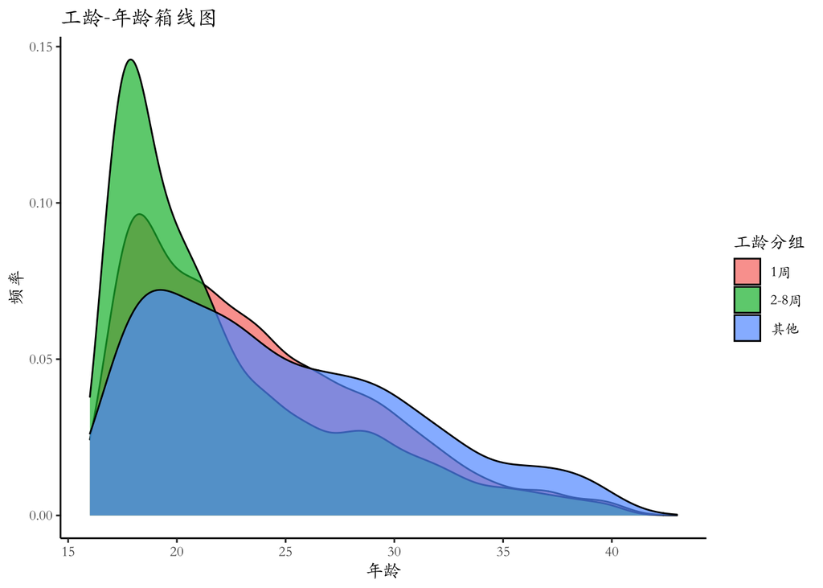

| 性别 | 工作时间 |
| --- | --- |
| 男 | 28.30084 |
| 女 | 33.01531 |

在年龄和工龄的相关“lm”线性回归中，只有籍贯是河南省雇员年龄喝工龄成正比，其他省份都是成反比，尤其是四川省随着工龄的增加年龄在降低，说明四川籍雇员的稳定性很高。

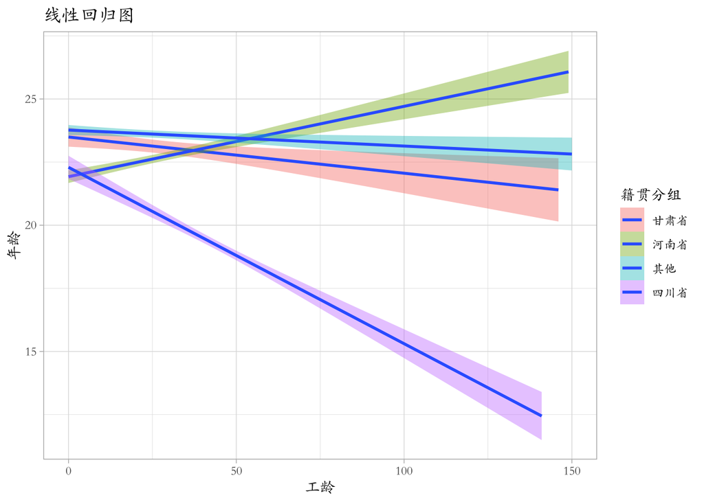

线性回归的性别比因素，男性雇员比女性雇员更加年轻。

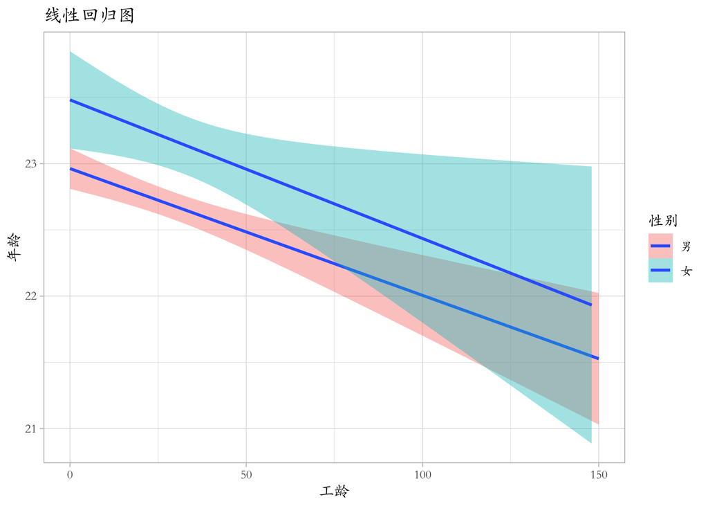

学历对工龄的影响也非常大，下图详细列出了各个学历层次的流失情况，印证了中专的高稳定性。

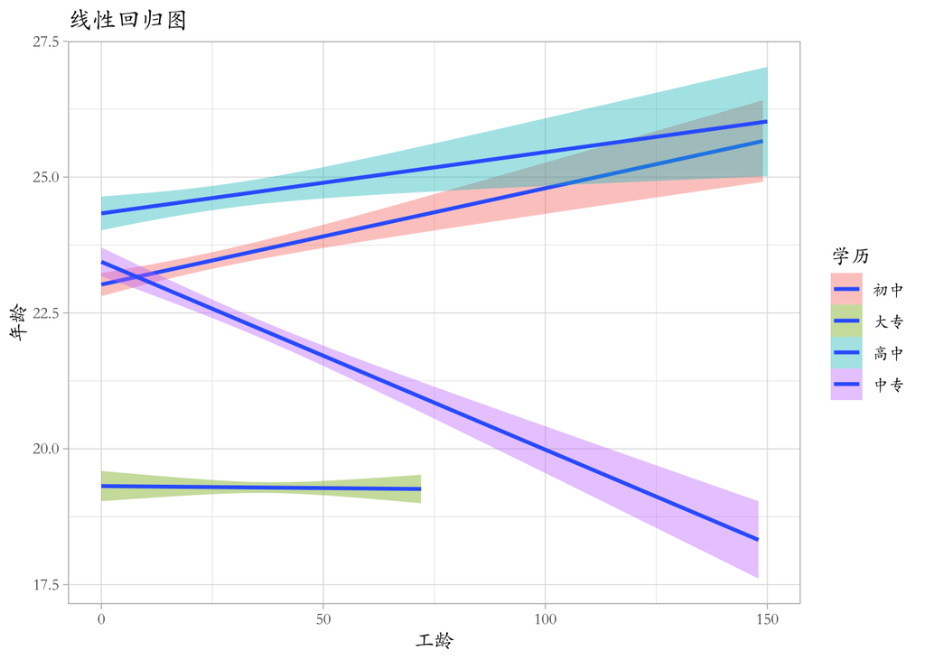

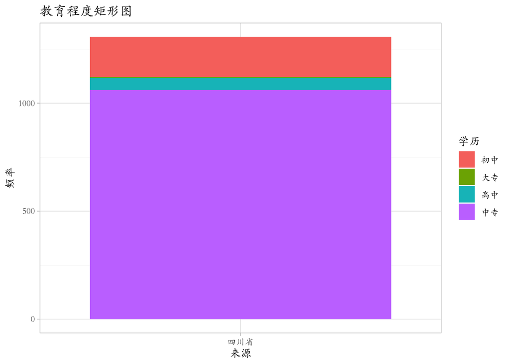

#### 3.3 流失率因素分析

相关分析主要处理数据集内各个变量之间的相关关系。我们需要对离职变量进行特征处理，赋值“0”或“1”。主要对性别、学历、籍贯、年龄与流失率进行整合分析。

| 性别 | 年龄 | 学历 | 籍贯分组 | 年龄分组 | 离职 |
| --- | --- | --- | --- | --- | --- |
| 男 | 31 | 初中 | 河南省 | 大于30岁 | 1 |
| 男 | 19 | 中专 | 四川省 | 小于20岁 | 1 |

##### 3.3.1 男性的流失率更高

男性比女性更容易流失，流失率高达0.71，整体流失率过高。

| 性别 | 流失率 |
| --- | --- |
| 男 | 0.71 |
| 女 | 0.67 |

小于20岁的人群流失率低于其他分组，与我们一般的年龄越低越容易流失的认知相反。

| 年龄分组 | 流失率 |
| --- | --- |
| 20-30岁 | 0.71 |
| 大于30岁 | 0.70 |
| 小于20岁 | 0.68 |

##### 3.3.3 职教背景稳定性高

从学历上看，初中和中专的流失率最低，分别是0.68和0.64，大专流失率达到100%。

| 学历 | 流失率 |
| --- | --- |
| 初中 | 0.68 |
| 大专 | 1.00 |
| 高中 | 0.72 |
| 中专 | 0.64 |

##### 3.3.4 特定地域流失率低

从来源地来看，结合上面分析可知，四川省来源的雇员流失率最低。

| 籍贯分组 | 流失率 |
| --- | --- |
| 甘肃省 | 0.73 |
| 河南省 | 0.73 |
| 其他 | 0.70 |
| 四川省 | 0.60 |

### 四、统计分析

统计方法分析，我们需要对变量进行正态分布检验，进而采用合适的方法分析雇员流失的问题。

#### 4.1 正态分布检验

对连续型变量工龄和年龄进行的正态分布检验，发现两个变量都非正态分布，又考虑到鉴于数据集的分类离散型变量较多，进而方差分析和回归方法不适合数据集，转而采用其他方法。

##### 4.1.1 QQ图

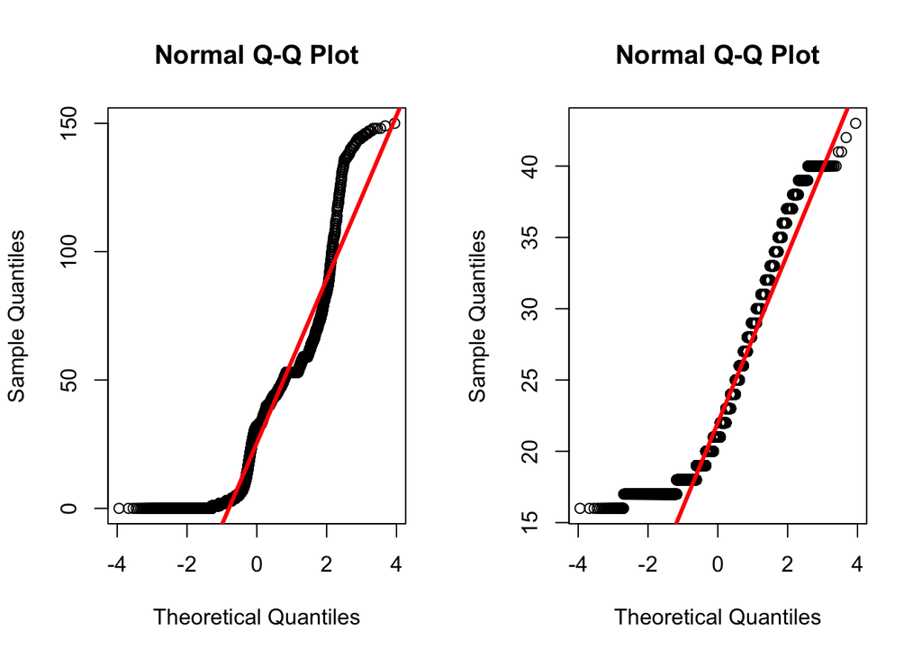

##### 4.1.2 shapiro假设检验

工龄的正态分布检验，p<0.05,说明数据非正态分布。

```
##
##  Shapiro-Wilk normality test
##
## data:  d
## W = 0.9, p-value <2e-16
```

年龄的正态分布检验，p<0.05,说明数据非正态分布。

```
##
##  Shapiro-Wilk normality test
##
## data:  y
## W = 0.9, p-value <2e-16
```

#### 4.2 logistic回归

鉴于数据集多为分类二项数据，我们拟采用逻辑回归来解释雇员流失的问题，通过年龄、学历、户籍等变量拟合模型。

##### 4.2.1 数值特征处理

首先对“离职”和“性别”进行因子化处理，便于拟合模型。

| 离职 | 性别 | 年龄 | 学历 | 籍贯分组 |
| --- | --- | --- | --- | --- |
| 是 | 男 | 31 | 初中 | 河南省 |

##### 4.2.2 拟合回归模型

采用逻辑回归方式，将离职与否作为预测变量，拟合模型。得到以下模型：

```r
fit_1<-glm(离职~性别+年龄+学历+籍贯分组,data=my,family = binomial())
summary(fit_1)
```

```
##
## Call:
## glm(formula = 离职 ~ 性别 + 年龄 + 学历 + 籍贯分组,
##     family = binomial(), data = my)
##
## Deviance Residuals:
##    Min      1Q  Median      3Q     Max
## -3.425  -1.392   0.821   0.893   1.122
##
## Coefficients:
##                Estimate Std. Error z value Pr(>|z|)
## (Intercept)     0.39409    0.09443    4.17  3.0e-05 ***
## 性别女         -0.32429    0.04038   -8.03  9.7e-16 ***
## 年龄            0.01784    0.00323    5.53  3.3e-08 ***
## 学历大专        4.94010    0.40905   12.08  < 2e-16 ***
## 学历高中        0.15852    0.05000    3.17   0.0015 **
## 学历中专       -0.06794    0.04065   -1.67   0.0947 .
## 籍贯分组河南省  0.09070    0.06432    1.41   0.1585
## 籍贯分组其他   -0.05994    0.06240   -0.96   0.3368
## 籍贯分组四川省 -0.15510    0.07660   -2.02   0.0429 *
## ---
## Signif. codes:  0 '***' 0.001 '**' 0.01 '*' 0.05 '.' 0.1 ' ' 1
##
## (Dispersion parameter for binomial family taken to be 1)
##
##     Null deviance: 22111  on 18079  degrees of freedom
## Residual deviance: 20844  on 18071  degrees of freedom
## AIC: 20862
##
## Number of Fisher Scoring iterations: 7
```

```r
fit_2<-fits<-glm(离职~性别+年龄+学历,data=my,family = binomial())
summary(fit_2)
```

```
##
## Call:
## glm(formula = 离职 ~ 性别 + 年龄 + 学历, family = binomial(),
##     data = my)
##
## Deviance Residuals:
##    Min      1Q  Median      3Q     Max
## -3.449  -1.409   0.819   0.893   1.085
##
## Coefficients:
##             Estimate Std. Error z value Pr(>|z|)
## (Intercept)  0.37174    0.07533    4.93  8.0e-07 ***
## 性别女      -0.32307    0.03979   -8.12  4.7e-16 ***
## 年龄         0.01899    0.00312    6.09  1.1e-09 ***
## 学历大专     4.94734    0.40897   12.10  < 2e-16 ***
## 学历高中     0.14877    0.04994    2.98  0.00289 **
## 学历中专    -0.13085    0.03685   -3.55  0.00038 ***
## ---
## Signif. codes:  0 '***' 0.001 '**' 0.01 '*' 0.05 '.' 0.1 ' ' 1
##
## (Dispersion parameter for binomial family taken to be 1)
##
##     Null deviance: 22111  on 18079  degrees of freedom
## Residual deviance: 20867  on 18074  degrees of freedom
## AIC: 20879
##
## Number of Fisher Scoring iterations: 7
```

| Resid. Df | Resid. Dev | Df | Deviance | Pr(>Chi) |
| --- | --- | --- | --- | --- |
| 18074 | 20867 | NA | NA | NA |
| 18071 | 20844 | 3 | 23 | 0 |

##### 4.2.3 回归模型评价

在fit_2模型中，我们发现离职率是1.45，那么女性的优势比将乘以0.72，中专学历优势比将乘以0.88，其他项如年龄、高中、大专学历将随着离职率增加而增加。

```
## (Intercept)      性别女        年龄    学历大专    学历高中    学历中专
##        1.45        0.72        1.02      140.80        1.16        0.88
```

模型的置信区间，范围从2.5%-97.5%。

```r
exp(confint(fit_2) )
```

```
##             2.5 % 97.5 %
## (Intercept)  1.25   1.68
## 性别女       0.67   0.78
## 年龄         1.01   1.03
## 学历大专    69.18 355.21
## 学历高中     1.05   1.28
## 学历中专     0.82   0.94
```

在过度离势的检验中，模型比值为1.2接近1，表明没有过度离势。

```r
deviance(fit_2)/df.residual(fit_2)
```

```
## [1] 1.2
```

#### 4.3 时间序列预测

为了进一步探究雇员流失的时间趋势，我们拟分析入职趋势和离职趋势，进而使用时间序列预测雇员流失的情况。

##### 4.3.1 雇员流失趋势

从入职时间上看，入职雇员在1月份是一个高峰期，此后进入速度放缓，可能与春招人员扩张有关。

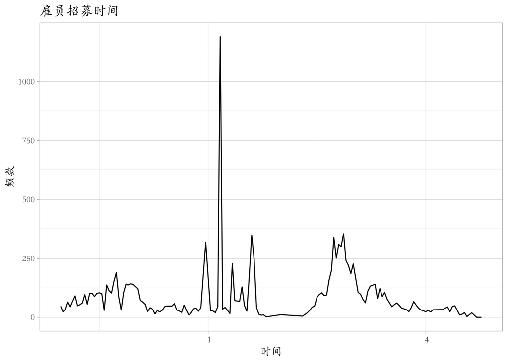

从离职时间上看，3月份左右是一个离职高峰期，有大批雇员离职。结合入职趋势观察离职趋势，可以发现入职高峰期后不到2个月左右迎来了离职高峰期。

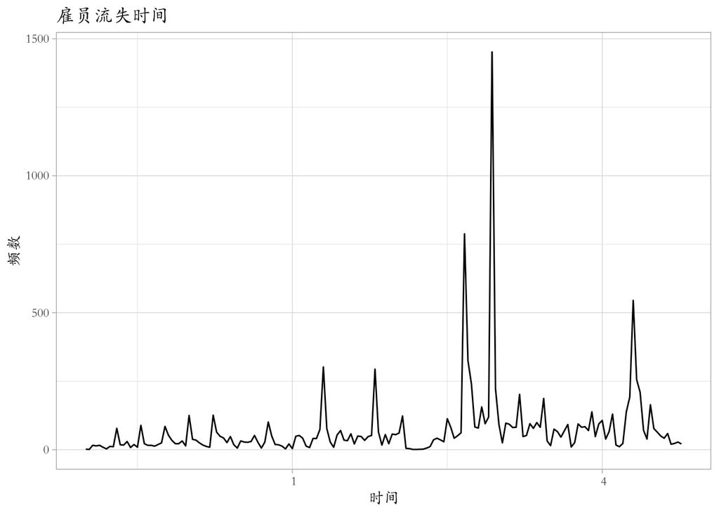

##### 4.3.2 时间数据处理

在数据中提取出所需的时间和频率数据，方便时间序列模型建立。经过分组聚合后提取出半年度雇员流失数据，作为接下来模型的初始数据。

提取出的时间序列，如表。

```r
myts
```

```
##       Jan  Feb  Mar  Apr May Jun Jul Aug Sep Oct  Nov  Dec
## 2018                                             1110  711
## 2019 1808 4045 2577 2392
```

```
## [1] 0
```

```r
dmyts<-diff(myts)
adf.test(dmyts)
```

```
##
##  Augmented Dickey-Fuller Test
##
## data:  dmyts
## Dickey-Fuller = NaN, Lag order = 1, p-value = NA
## alternative hypothesis: stationary
```

通过对ACF和PACF的绘图，我们发现数据ACF和PACF的值，因此选择模型（0，1，1）的取值范围。

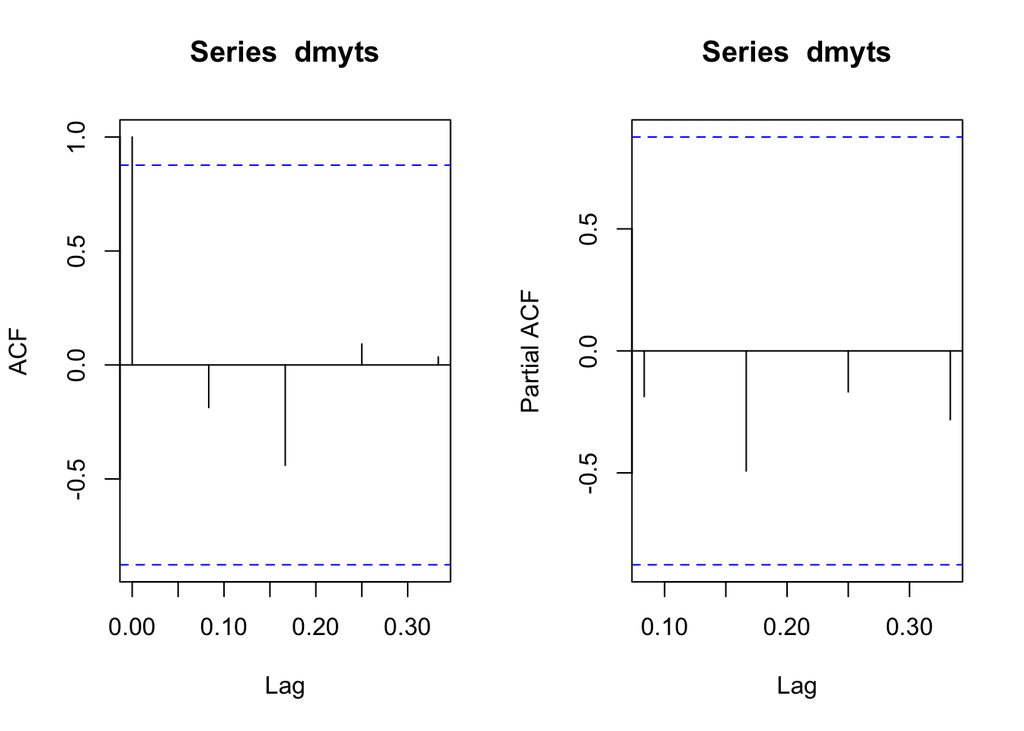

##### 4.3.3 时间序列拟合

拟合模型fit,模型AIC为90，移动平均系数为-0.24，平均错误百分比为2%。

```r
fit<-arima(myts,order=c(0,1,1))
fit
```

```
##
## Call:
## arima(x = myts, order = c(0, 1, 1))
##
## Coefficients:
##         ma1
##       -0.24
## s.e.   0.61
##
## sigma^2 estimated as 1643489:  log likelihood = -43,  aic = 90
```

```r
accuracy(fit)
```

```
##               ME RMSE MAE MPE MAPE MASE   ACF1
## Training set 304 1170 857   2   37  0.8 -0.064
```

##### 4.3.4 预测模型评价

经过对模型残差的正态分布绘图和显著性检验，我们发现数据基本围绕回归线分布，p>0.05,残差分布不显著，ARIMA模型基本上拟合了数据。

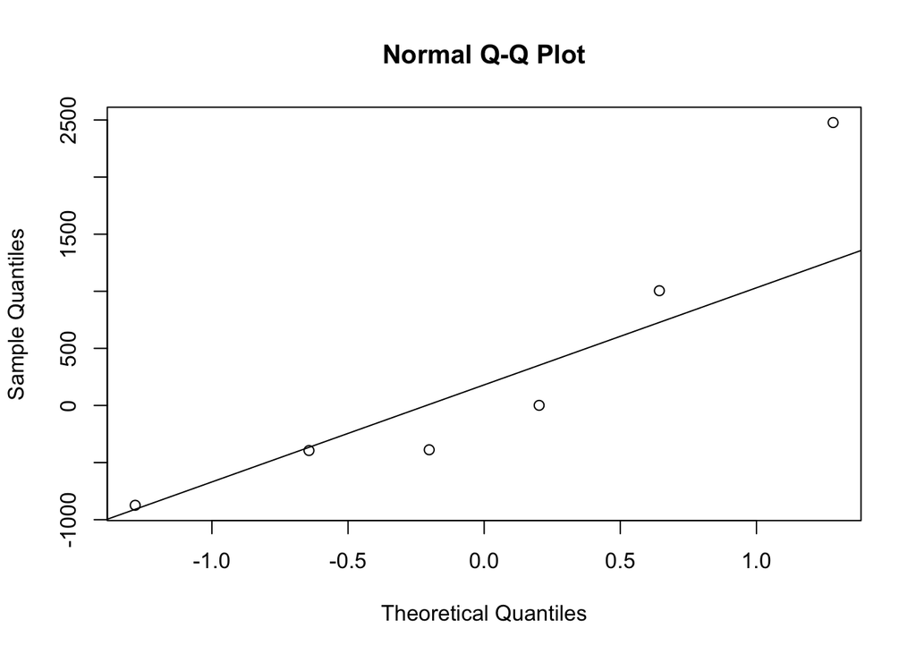

```
##
##  Box-Ljung test
##
## data:  fit$residuals
## X-squared = 0.04, df = 1, p-value = 0.8
```

##### 4.3.5 流失率的预测

在ARIMA模型建立以后，我们预测了未来一年的流失情况，如下图。如不采取相应的措施，雇员的流失将不会停止。

```r
forecast(fit,12)
```

```
##          Point Forecast Lo 80 Hi 80 Lo 95 Hi 95
## May 2019           2487   844  4130   -26  4999
## Jun 2019           2487   423  4550  -670  5643
## Jul 2019           2487    74  4899 -1203  6176
## Aug 2019           2487  -230  5203 -1668  6641
## Sep 2019           2487  -503  5476 -2086  7059
## Oct 2019           2487  -754  5727 -2469  7442
## Nov 2019           2487  -986  5959 -2824  7797
## Dec 2019           2487 -1204  6177 -3157  8130
## Jan 2020           2487 -1409  6383 -3472  8445
## Feb 2020           2487 -1605  6578 -3770  8744
## Mar 2020           2487 -1791  6764 -4055  9029
## Apr 2020           2487 -1970  6943 -4329  9302
```

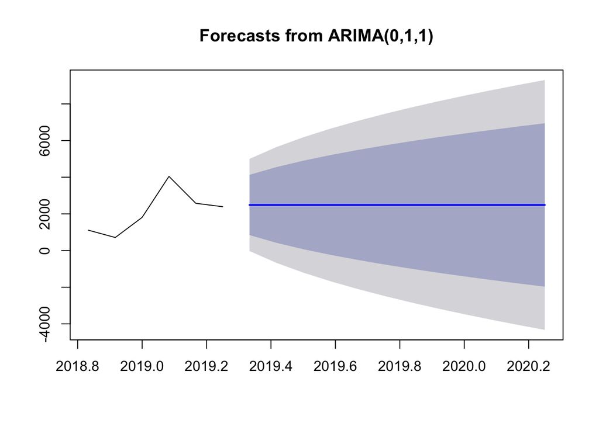

### 五、结论建议

本部分将总结数据分析的结果并提出相应雇员流失问题的建议。

#### 5.1 结论

##### 5.1.1 新生代蓝领，群体特征明显

从上述分析结果来看，雇员整体上属于新生代蓝领群体，各个方面的特征相当显著。

[output not shown]

##### 5.1.2 流失时间集中，呈双峰分布

雇员流失特征中显示，企业雇员流失严，说明企业的流动出现较大的问题。在时间密度图和流失趋势图中显示，雇员的流失存在一定的趋势。

```
1.半年流失近7成雇员，仅剩下最初招募的3成人留存。
2.存在7天和50天的流失高峰期，此期间人员大批流失。
3.峰值后期“长尾”状态下，企业雇员流失日趋平缓。
4.男性比女性更容易流失，流失率高达71%，女性为67%。
5.中专流失率显著低于其他学历，职业教育背景更稳定。
6.各个地区流失率不一致，总体上川籍中专背景更稳定。
```

##### 5.1.3 整体上动荡，变量作用不一

基于数据画像、流失率分析和回归模型等方面的数据分析。

[output not shown]

#### 5.2 建议

#### 5.2.1 压平流失曲线

面对近7成的流失率，第一件紧要的事情就是压平流失曲线，减少雇员的大批流失带来的工作环境恶化。

```
1.改善员工工作环境，加大员工关怀行动，从面试、入职、工作、离职全方位入手。
2.薪资与离职的挂钩，一是奖励措施，留存时间越长奖金越多；二是对应的惩罚措施。
3.设置离职人数限制，规定离职排队日期，将离职曲线拉平，减少短时间雇员批量流失。
4.对入职雇员，以一周和一个月为期限，进行二次专业的心里疏导，关注员工健康。
5.设置特殊的雇员流失处理人员，梳理问题，总结上报，制定行动方案，减少负面情绪。
```

#### 5.2.2 优化雇员结构

根据上述分析的数据画像、流失特征以及回归模型，我们将针对性的处理方案，以此提降雇员流失的可能性，从招牌的源头入手。

```
1.大量招收具有中等职业教育水平的雇员，提高企业雇员熟练度和忠诚度。
2.平衡性别比，招募员工提高女员工的比例，提高企业工作人员的稳定性。
3.来源地人员配额设置，提高粘度高地区人群的比例，缓解同乡等因素的影响。
4.招收的年龄段适当提高18——20岁和30岁以上人群的比例，拉长流失的长尾。
5.注意招聘的高峰期，尽可能的优化雇员结构，提高企业雇员的留存度。
```

#### 5.2.3 改善企业管理

鉴于雇员的短期离职行为，反映在企业管理之中，结合企业雇员的深度调研，给出管理中的建议。

```
1.调整薪酬水平，有针对性的以提高企业粘度为目标，提高薪资。
2.整顿基层管理，调整基层不称职的管理。严格制度执行，适度宽松管理。
3.建立雇员反馈渠道，如员工监督委员会，让员工的声音可以被上层听到。
4.通畅员工成长渠道，开展内部培训或职业教育、考证等措施，提高个人价值。
5.鼓励各种形式娱乐活动，给员工一个轻松的工作环境，统一组织团建等。
```